# QMM1002 Case Study 1 FethiAbdulmenan

Fethi Abdulmenan

2024-10-20

# Case Study 1

## Introduction

As a full-time student balancing part-time work, I constantly juggle multiple responsibilities. To gain a better understanding of how I manage my time and how my daily activities relate to one another, I conducted a self-study over two semesters. Semester 1 spanned from May 10, 2024, to August 13, 2024, while Semester 2 began on September 9, 2024, and is ongoing as of October 17, 2024. The personalized data set included both quantitative and qualitative variables. These variables are:

Dataset Description

| Variable | Description | Type |
| --- | --- | --- |
| Date(time) | Date of data collection | Identifier |
| Class(hours) | Records the time i spend attending lectures or labs | Quantitative |
| Study(hours) | Records time I dedicated to academic work outside of Class | Quantitative |
| Sleep(hours) | Records the amount of sleep I get each night(hours) | Quantitative |
| Cup of Coffee( cups) | Records my coffee consumption habits( cups) | Quantitative |
| News(Yes/No) | Records whether I watched the news or not | Nominal Categorical |
| Excercise | Indicates type of exercise i am practicing that day | Nominal Categorical |
| Mood(1to5) | Reflects my overall emotional state on a scale of 1(very poor to 5 | Ordinal Scale |
| Emails( count of emails) | Represents the number of Emails I send or receive daily | Quantitative |
| Semester(count) | Categorize data into groups | Qualitative |

In this report, I will analyze one quantitative variables: study hours, sleep hours, and the number of emails I send or receive daily. As someone returning to academics after a few years off, establishing a study routine has been a critical goal. I have historically struggled with procrastination, and developing a regular study routine is essential for academic success. During Semester 1, I was able to create a successful and well-managed time routine, and I want to assess whether that routine carried over into Semester 2.Another primary concern has been managing sleep. Although I understand the importance of sleep for health and productivity, I often struggle with insomnia, especially during the weekdays, and feel exhausted by the end of the week. Last year, I managed to maintain a reasonably healthy average of around 7 hours of sleep per night, and I want to evaluate whether that habit has continued into Semester 2 and assess how my sleep patterns have evolved throughout the year. Additionally, I want to investigate how emails, particularly those related to work, impact my daily routine. During the weekdays, emails keep me busy, but I make a conscious effort to disconnect on weekends by avoiding emails altogether. Emails were a source of stress for me during the first half of Semester 1, but after making some changes in how I manage them, I had a better handle on the situation in the second half of Semester 1. I want to determine if this improved trend is continuing in Semester 2.

To explore these aspects, I have focused on the following three main questions, which will serve as the primary goals of this report:

### Report Goals

1. What do you do in a day?
2. Do you spend your days how you expect?
3. Is any difference in how you spend your time this semester compared to last semester

To analyze this personalized data, I will employ various statistical methods. I will use confidence intervals to estimate the ranges for my average study hours and sleep patterns. I will conduct hypothesis testing to assess whether my study hours, sleep patterns, and email-related activities differ significantly from my expectations. Additionally, I will apply two-sample tests to compare how I spend my time across Semester 1 and Semester 2, using the appropriate test, whether that be a two-sample t-test, pooled test, or paired test.

By analyzing this data, I hope to gain deeper insights into how I spend my time each day and whether my expectations align with reality. Additionally, I want to identify any differences in how I spend my time between Semester 1 and Semester 2 and use these insights to better manage my time and daily activities going forward.

### Summary Statistics

summary statistics

| Variable | Mean | Standard Deviation |
| --- | --- | --- |
| Study(hours) | 3.9185185 | 1.6797826 |
| Sleep(hours) | 6.9777778 | 0.8439129 |
| Email(qty) | 6.6962963 | 3.5138831 |

The average hours i spend studying is 3.92 with a standard deviation of 2

The average hours i spend sleeping is 6.98 with a standard deviation or 1

The average hours i spend sending or receiving Emails is 6.7 with a standard deviation of 3.51

### Conditions

How do my quantitative variables behave? do they meet the conditions for using descriptive statistical methods like hypothesis test and conditional intervals?

We will check the four conditions required to use the t-distribution for each or our variables:

#### Study Hours

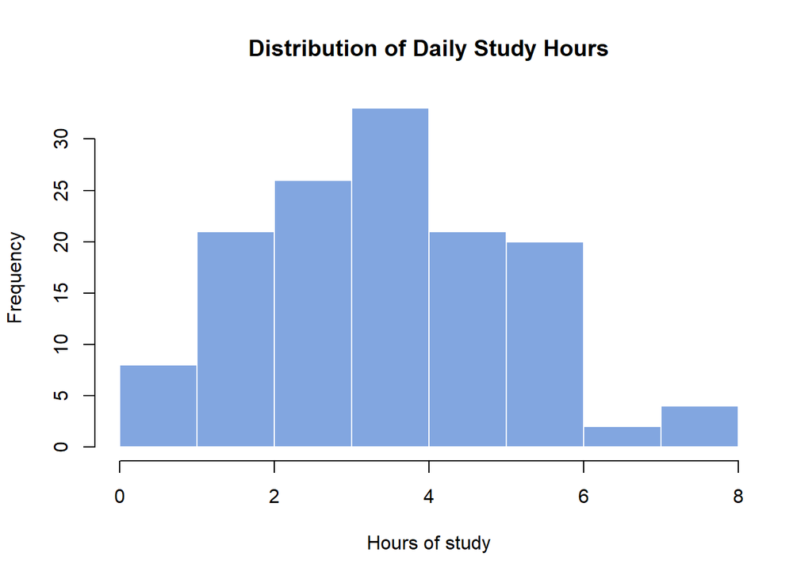

```r
hist(pd$Study, xlab="Hours of study", main="Distribution of Daily Study Hours", border='white' ,col ='#82a6e0')
```

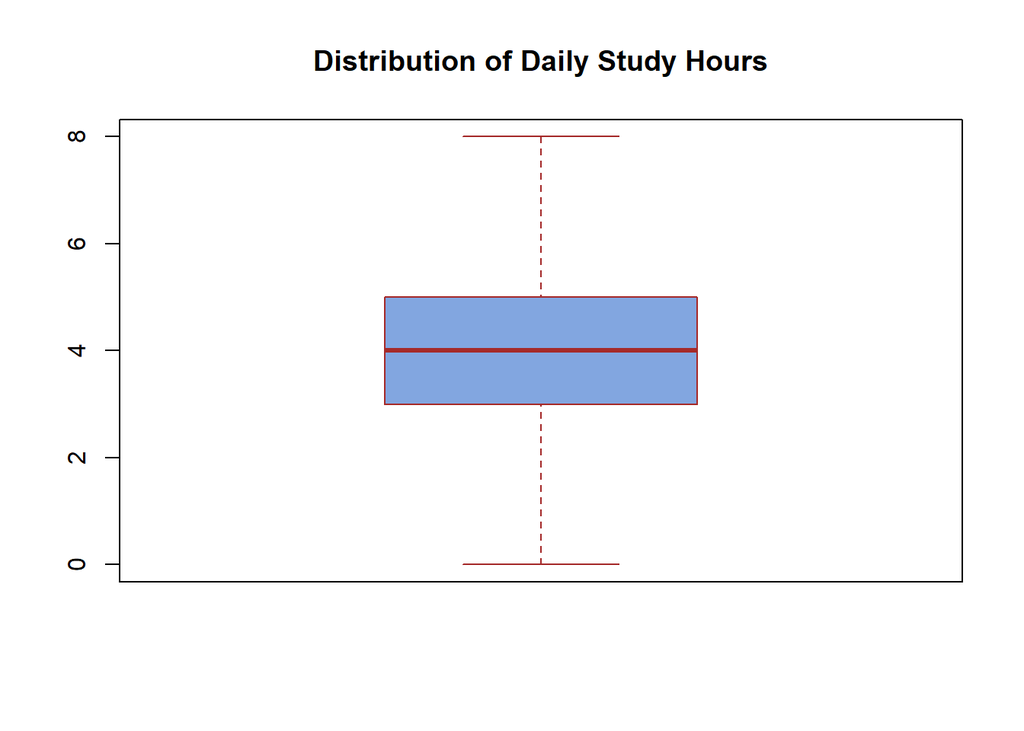

```r
boxplot(pd$Study, main="Distribution of Daily Study Hours",ylim=c(0,8), border = 'brown', col='#82a6e0')
```

```r
shapiro.test(pd$Study)
```

```
##
##  Shapiro-Wilk normality test
##
## data:  pd$Study
## W = 0.96129, p-value = 0.0007106
```

```r
library(ggplot2)
```

The histogram appears uni-modal and somewhat normally distributed with a slight skewness to the left (negatively skewed) with most of the data points clustering around the middle and upper study hours (2-6 hours).The box plot appears to be relatively symmetrical with the median line almost in the middle , suggesting that the distribution of study hours is balanced around the median.There are no outliers indicated in this box plot.

#### Sleep Hours

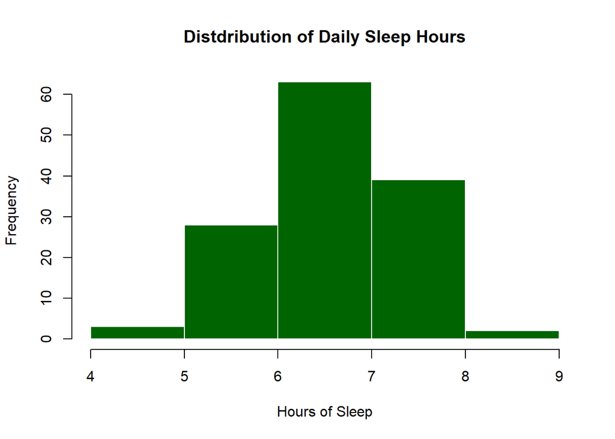

```r
hist(pd$Sleep, xlab="Hours of Sleep", main="Distdribution of Daily Sleep Hours",breaks = 7 ,border='white' ,col ='darkgreen')
```

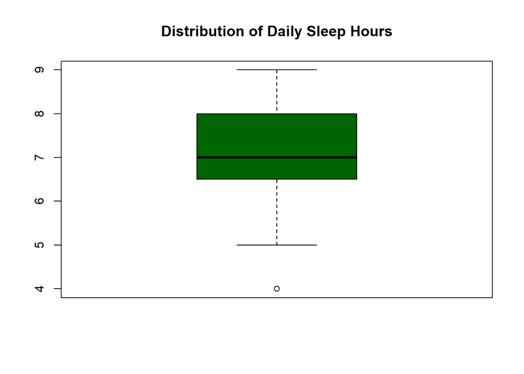

```r
boxplot(pd$Sleep, main="Distribution of Daily Sleep Hours", border = 'black', col='darkgreen')
```

```r
shapiro.test(pd$Sleep)
```

```
##
##  Shapiro-Wilk normality test
##
## data:  pd$Sleep
## W = 0.89635, p-value = 3.14e-08
```

The histogram of daily sleep hours appears to be unimodal and somewhat follows a normal distribution with a slight left skew (negative skewness). The boxplot shows that the median is positioned slightly closer to the bottom quartile (Q1), but it still indicates a relatively symmetrical distribution. One interesting observation is that there is one visible outlier below the lower bound, identified as a sleep time of 4 hours. Upon further reflection, I can see that on 03-Jun-24, I only had 4 hours of sleep, which was the night I was prepping for a new job interview the next day. This personal event explains the outlier and shows how my daily activities can impact sleep variability.

##### Conditions of Validity for T-tests and confidence Intervals

1. **Independence:**My sleep hours are essentially random, so I don’t foresee any issues with independence. Each day’s sleep time doesn’t affect the next, meaning the data points are independent of one another. The condition is met
2. **Randomization**:: Although my data wasn’t randomly selected, I can introduce randomization through sampling. By taking a random sample from my dataset, I can add an element of randomness, making the analysis more valid. This allows me to perform meaningful tests like t-tests and confidence intervals, which typically assume random sampling
3. **10% condition**:Since I recorded my Sleep hours for only a small number of days, and there are many more days in a semester or year, this condition is satisfied. My data represents just a small portion of all the possible days, so it meets the requirement
4. **Nearly Normal Condition:**The histogram of daily sleep hours appears to be unimodal and somewhat follows a normal distribution with a slight left skew (negative skewness). The boxplot shows that the median is positioned slightly closer to the bottom quartile (Q1), but it still indicates a relatively symmetrical distribution. The IQR is approximately 1.5 hours, meaning that the middle 50% of my daily sleep hours fall within a range of 6.5 to 8 hours. Additionally, there is one visible outlier below the lower bound, identified as a sleep time of 4 hours. The lower whisker of the boxplot is longer than the upper whisker, indicating that the data points below the lower quartile (Q1) are more spread out than those above the upper quartile (Q3).

   To further investigate, we performed the Shapiro-Wilk test. The Shapiro-Wilk test gave a result of W = 0.89635 and a p-value = 3.14e-08, which is much less than the alpha value of 0.05. This suggests that the data isn’t perfectly normal. However, since I am working with a larger sample size, the Shapiro-Wilk test can be very sensitive and may flag small deviations even when the data is close to normal.

   Given that the histogram appears reasonably normally distributed, and the boxplot is relatively symmetric with only one outlier, we can reasonably assume that the data is close enough to normal for conducting a t-test and confidence interval analysis. The condition for near-normality is met.

#### Emails

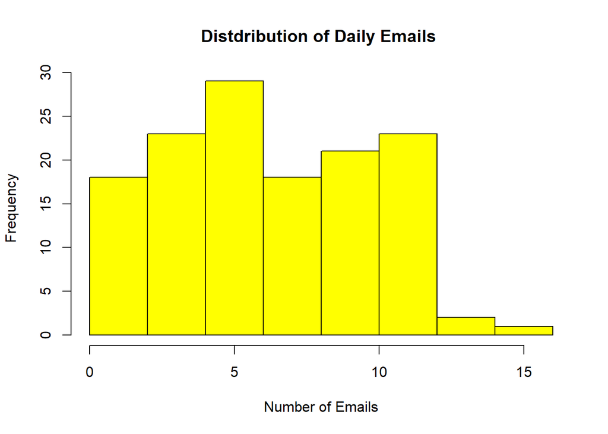

```r
hist(pd$Emails, xlab="Number of Emails", main="Distdribution of Daily Emails ", border='black' ,col ='yellow')
```

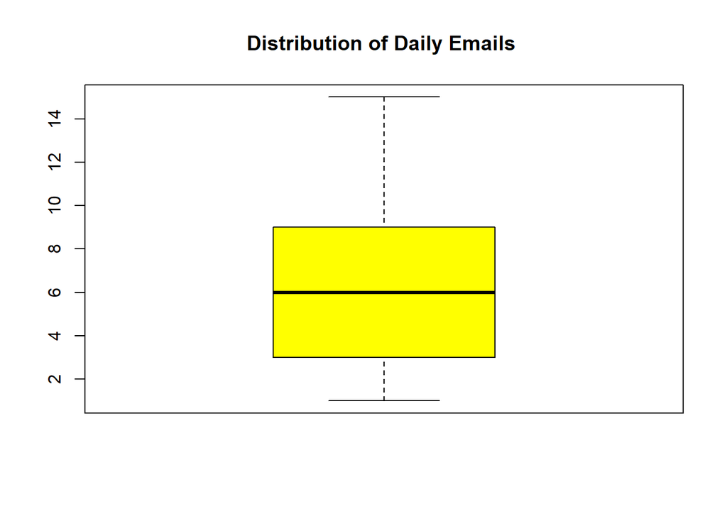

```r
boxplot(pd$Emails, main="Distribution of Daily Emails ", border = 'black', col='yellow')
```

```r
shapiro.test(pd$Emails)
```

```
##
##  Shapiro-Wilk normality test
##
## data:  pd$Emails
## W = 0.93428, p-value = 5.838e-06
```

The histogram of daily emails appears to be uni modal and somewhat follows a normal distribution with a slight right skew (positive skewness). The box plot shows that the median is positioned roughly in the center of the interquartile range (IQR), indicating a relatively symmetrical distribution.